# EcoPractical

Team 8

13/12/2021

# Prophet Model

```
• It is a nonlinear regression model
• Prophet is a procedure for forecasting time series data based on an additive model where non-linear trends are fit with yearly, weekly, and daily seasonality, plus holiday effects
• It works best with time series that have strong seasonal effects and several seasons of historical data.
• It is robust to missing values and shift in trend, handles outliers well
• Modeling holidays and special events - [Link to refer](https://facebook.github.io/prophet/docs/seasonality,_holiday_effects,_and_regressors.html)
• The model is estimated using a Bayesian approach to allow for automatic selection of the change points and other model characteristics.
```

## References of the work

- [Time Series Forecasting With Prophet In R](https://levelup.gitconnected.com/time-series-forecasting-with-prophet-in-r-a9ee81dc82e1)
- [Seasonality, Holiday Effects, And Regressors](https://facebook.github.io/prophet/docs/seasonality,_holiday_effects,_and_regressors.html)
- [Generate Quick and Accurate Time Series Forecasts using Facebook’s Prophet (with Python & R codes)](https://www.analyticsvidhya.com/blog/2018/05/generate-accurate-forecasts-facebook-prophet-python-r/)

## Import all the required libraries

```r
library(tidyverse)
```

```r
library(stringr)
library(dplyr)
library(tidyr)
library(ggplot2)
library(tidyverse)
library(prophet)
#install.packages("prophet")
```

## Load training csv file

```r
train <- readr::read_csv("train.csv")
```

## Load test file

```r
test <- readr::read_csv("test.csv")
```

# View few enteries of train data

```r
head(train)
```

```
## # A tibble: 6 x 6
##   application_date segment branch_id state       zone  no_of_applicants
##   <chr>              <dbl>     <dbl> <chr>       <chr>            <dbl>
## 1 01-04-2017             1         1 WEST BENGAL EAST                40
## 2 01-04-2017             1         3 DELHI       NORTH               58
## 3 01-04-2017             1         5 KARNATAKA   SOUTH               10
## 4 01-04-2017             1         7 WEST BENGAL EAST                 2
## 5 01-04-2017             1         8 WEST BENGAL EAST                13
## 6 01-04-2017             1         9 WEST BENGAL EAST                11
```

## Check total Null values in the train data

```r
sum(is.na(train))
```

```
## [1] 43868
```

## Check null values of each columns

```r
lapply(train,function(x) { length(which(is.na(x)))})
```

```
## $application_date
## [1] 2970
##
## $segment
## [1] 2970
##
## $branch_id
## [1] 15994
##
## $state
## [1] 2970
##
## $zone
## [1] 15994
##
## $no_of_applicants
## [1] 2970
```

> There are 2970 completely empty rows in data so we will remove those rows For segement 2 branch id and zone are missing, so we will first deselect those columns and then drop the null values to avoid losing 2nd segemsnt data

```r
raw_data = subset(train, select = -c(branch_id,zone) )
if (sum(is.na(raw_data))!= 0)
{
  data <- na.omit(raw_data)
} else
{
  data <- raw_data
}
head(data)
```

```
## # A tibble: 6 x 4
##   application_date segment state       no_of_applicants
##   <chr>              <dbl> <chr>                  <dbl>
## 1 01-04-2017             1 WEST BENGAL               40
## 2 01-04-2017             1 DELHI                     58
## 3 01-04-2017             1 KARNATAKA                 10
## 4 01-04-2017             1 WEST BENGAL                2
## 5 01-04-2017             1 WEST BENGAL               13
## 6 01-04-2017             1 WEST BENGAL               11
```

## Check unique values in segement

```r
unique(data$segment)
```

```
## [1] 1 2
```

## Summary of the new data generated after dropping of null values

```r
summary(data)
```

```
##  application_date      segment         state           no_of_applicants
##  Length:77432       Min.   :1.000   Length:77432       Min.   :    0.0
##  Class :character   1st Qu.:1.000   Class :character   1st Qu.:    0.0
##  Mode  :character   Median :1.000   Mode  :character   Median :   17.0
##                     Mean   :1.168                      Mean   :  184.9
##                     3rd Qu.:1.000                      3rd Qu.:   60.0
##                     Max.   :2.000                      Max.   :13787.0
```

## Convert application date in proper date format

```r
data$application_date <- as.Date(data$application_date, "%d-%m-%Y")
```

```r
head(data$application_date)
```

```
## [1] "2017-04-01" "2017-04-01" "2017-04-01" "2017-04-01" "2017-04-01"
## [6] "2017-04-01"
```

## Convert application date in proper date format

```r
train$application_date <- as.Date(train$application_date, "%d-%m-%Y")
test$application_date <- as.Date(test$application_date, "%d-%m-%Y")
```

```r
head(data$application_date)
```

```
## [1] "2017-04-01" "2017-04-01" "2017-04-01" "2017-04-01" "2017-04-01"
## [6] "2017-04-01"
```

## Split the dataset into two seperate dataframe based on 2 segement

## Splitting test data

```r
test_s1 <- test[which(test$segment == 1),]

test_s2 <- test[which(test$segment == 2),]
```

```r
class(test$application_date)
```

```
## [1] "Date"
```

## Splitting train data based on 2 different segemnt

```r
# splitting dataframe based on segments 1 and 2
train_s1 <- train[which(train$segment == 1),]%>%
  group_by(application_date)

train_s2 <- train[which(train$segment == 2),]%>%
  group_by(application_date)
```

```r
train_s1
```

```
## # A tibble: 64,408 x 6
## # Groups:   application_date [776]
##    application_date segment branch_id state         zone  no_of_applicants
##    <date>             <dbl>     <dbl> <chr>         <chr>            <dbl>
##  1 2017-04-01             1         1 WEST BENGAL   EAST                40
##  2 2017-04-01             1         3 DELHI         NORTH               58
##  3 2017-04-01             1         5 KARNATAKA     SOUTH               10
##  4 2017-04-01             1         7 WEST BENGAL   EAST                 2
##  5 2017-04-01             1         8 WEST BENGAL   EAST                13
##  6 2017-04-01             1         9 WEST BENGAL   EAST                11
##  7 2017-04-01             1        10 WEST BENGAL   EAST                 0
##  8 2017-04-01             1        11 WEST BENGAL   EAST                 9
##  9 2017-04-01             1        13 TAMIL NADU    SOUTH                1
## 10 2017-04-01             1        14 UTTAR PRADESH EAST                 0
## # … with 64,398 more rows
```

```r
unique(train_s1$segment)
```

```
## [1] 1
```

## Subsetting the train and test data for model building and prediction

```r
df_1 = subset(train_s1, select = c(application_date,no_of_applicants) )
df_2 = subset(train_s2, select = c(application_date,no_of_applicants) )
```

```r
test_s1 = subset(test_s1, select = c(application_date) )
test_s2 = subset(test_s2, select = c(application_date) )
```

```r
head(test_s1)
```

```
## # A tibble: 6 x 1
##   application_date
##   <date>
## 1 2019-06-06
## 2 2019-06-07
## 3 2019-06-08
## 4 2019-06-09
## 5 2019-06-10
## 6 2019-06-11
```

## Building 4 test and train dataset with variable names “ds” and “y” representing the application_date and no of application counts to accommodate prophet

```r
test_s1 <- mutate (
test_s1,
ds = application_date,  # Create new ds column from date using mutate

)

test_s2 <- mutate (
test_s2,
ds = application_date,  # Create new ds column from date using mutate

)
test_s1 = subset(test_s1, select = c(ds) )
test_s2 = subset(test_s2, select = c(ds) )
```

```r
df_1 <- mutate (
df_1,
ds = application_date,  # Create new ds column from date using mutate
y = no_of_applicants   # Create new y column from value using mutate
)

df_2 <- mutate (
df_2,
ds = application_date,  # Create new ds column from date using mutate
y = no_of_applicants   # Create new y column from value using mutate
)
```

# Prophet Model building

```r
# Model building
m = prophet(df_1)
```

```
## Disabling daily seasonality. Run prophet with daily.seasonality=TRUE to override this.
```

```r
future = make_future_dataframe(m, periods = 7)
forecast = predict(m, future)
```

```r
tail(forecast)
```

```
##             ds    trend additive_terms additive_terms_lower
## 778 2019-06-07 46.85045    -1.85386906          -1.85386906
## 779 2019-06-08 46.87068    -4.94688345          -4.94688345
## 780 2019-06-09 46.89091   -15.39102026         -15.39102026
## 781 2019-06-10 46.91114     4.66403979           4.66403979
## 782 2019-06-11 46.93137    -0.07918095          -0.07918095
## 783 2019-06-12 46.95160     5.89028725           5.89028725
##     additive_terms_upper      weekly weekly_lower weekly_upper     yearly
## 778          -1.85386906   1.1679517    1.1679517    1.1679517 -3.0218207
## 779          -4.94688345  -2.4788945   -2.4788945   -2.4788945 -2.4679890
## 780         -15.39102026 -13.4560067  -13.4560067  -13.4560067 -1.9350135
## 781           4.66403979   6.0904765    6.0904765    6.0904765 -1.4264367
## 782          -0.07918095   0.8662019    0.8662019    0.8662019 -0.9453828
## 783           5.89028725   6.3848261    6.3848261    6.3848261 -0.4945389
##     yearly_lower yearly_upper multiplicative_terms multiplicative_terms_lower
```

[output cut: 20 more lines]

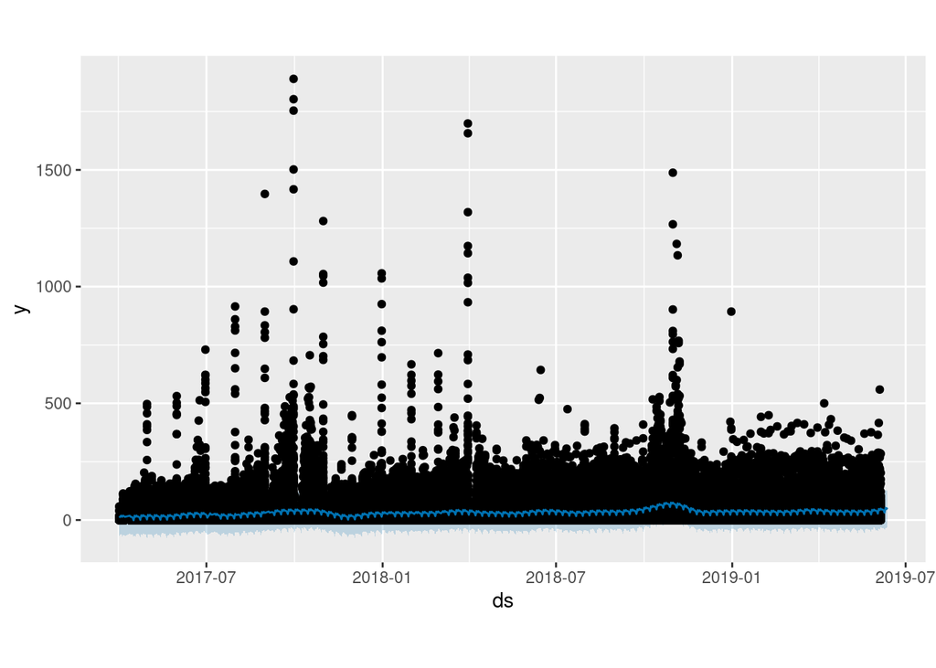

```r
plot(m, forecast)
```

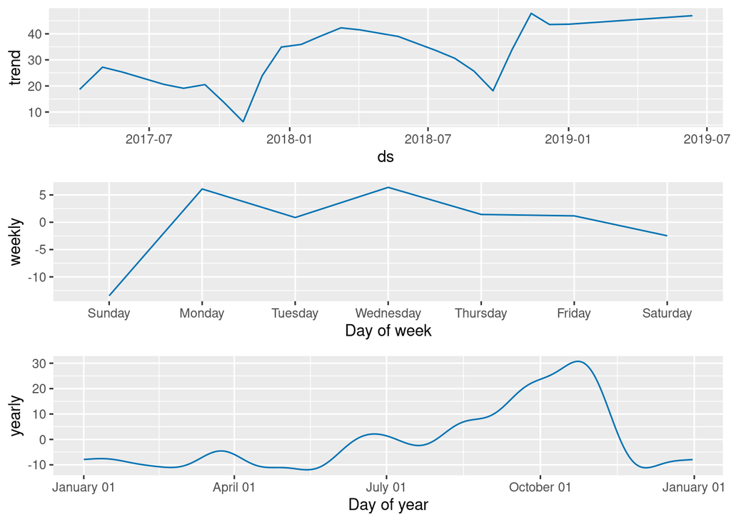

```r
prophet_plot_components(m, forecast)
```

## Prophet Model Building for segement 1 data with weekly and daily sesonality set as true for better forecast plot

```r
# Model building
m = prophet(df_1,weekly.seasonality=TRUE, daily.seasonality=TRUE)
future = make_future_dataframe(m, periods = 30)
forecast = predict(m, future)
```

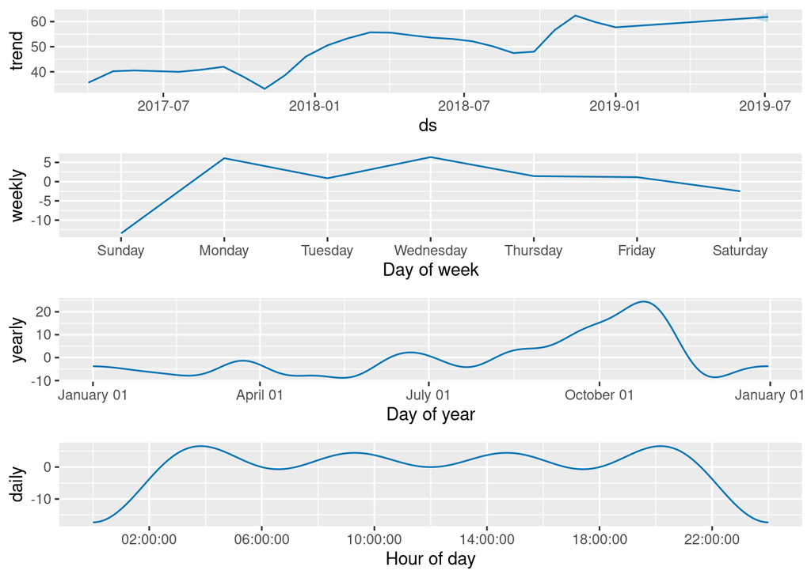

```r
prophet_plot_components(m, forecast)
```

## predicting the values for test dataset for segment 1 and storing in y_s1

```r
y_s1 <- predict(m, test_s1)
```

```r
nrow(test_s1)
```

```
## [1] 30
```

## Adding predicted values for in test dataset where segement is 1 for no. of applicants

```r
test[test$segment==1, 'no_of_applicants'] <- y_s1$yhat
```

## Prophet Model Building for segement 2 data with weekly and daily sesonality set as true for better forecast plot

```r
# Model building
m_2 = prophet(df_2,weekly.seasonality=TRUE, daily.seasonality=TRUE)
future_2 = make_future_dataframe(m_2, periods = 30, include_history = TRUE)
forecast_2 = predict(m_2, future_2)
```

## Plotting the forcast values

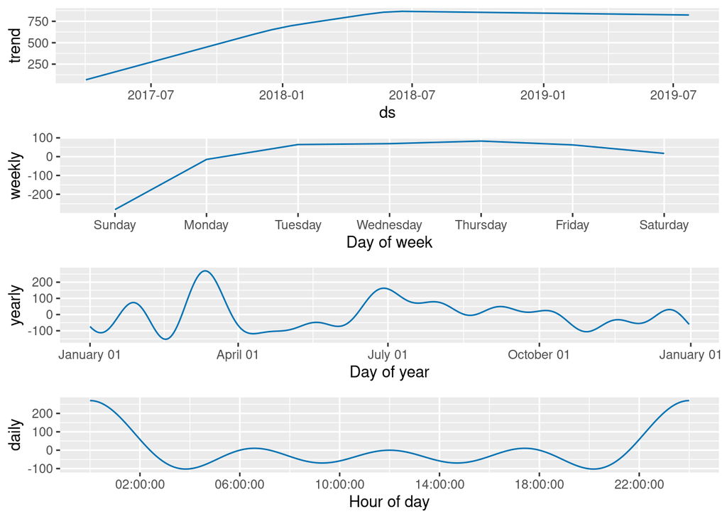

```r
prophet_plot_components(m_2, forecast_2)
```

## Summary of the model

```r
summary(m_2)
```

```
##                         Length Class      Mode
## growth                    1    -none-     character
## changepoints             25    POSIXct    numeric
## n.changepoints            1    -none-     numeric
## changepoint.range         1    -none-     numeric
## yearly.seasonality        1    -none-     character
## weekly.seasonality        1    -none-     logical
## daily.seasonality         1    -none-     logical
## holidays                  0    -none-     NULL
## seasonality.mode          1    -none-     character
## seasonality.prior.scale   1    -none-     numeric
## changepoint.prior.scale   1    -none-     numeric
## holidays.prior.scale      1    -none-     numeric
## mcmc.samples              1    -none-     numeric
## interval.width            1    -none-     numeric
## uncertainty.samples       1    -none-     numeric
## specified.changepoints    1    -none-     logical
## start                     1    POSIXct    numeric
## y.scale                   1    -none-     numeric
## logistic.floor            1    -none-     logical
## t.scale                   1    -none-     numeric
## changepoints.t           25    -none-     numeric
## seasonalities             3    -none-     list
## extra_regressors          0    -none-     list
## country_holidays          0    -none-     NULL
## stan.fit                  4    -none-     list
## params                    6    -none-     list
## history                   7    grouped_df list
## history.dates           814    POSIXct    numeric
## train.holiday.names       0    -none-     NULL
## train.component.cols      5    data.frame list
## component.modes           2    -none-     list
## fit.kwargs                0    -none-     list
```

## Predicting values for in test dataset where segement is 2 for no. of applicants

```r
y_s2 <- predict(m_2, test_s2)
```

## length of test data

```r
nrow(test)
```

```
## [1] 60
```

## Adding predicted values for in test dataset where segement is 2 for no. of applicants

```r
test[test$segment==2, 'no_of_applicants'] <- y_s2$yhat
```

## Saving the test data with predicted values as output_files.csv

```r
write.csv(test, "output_files.csv")
```